# 61524931_陈彦明_astronaut_jewelry

## Step 1: 导入库与载入宇航员图像

[figure not shown]

```python
import numpy as np
import matplotlib.pyplot as plt
from skimage import data, color, filters, feature, morphology, measure, util
from scipy import ndimage as ndi

# 优先使用 OpenCV
try:
    import cv2
    OPENCV_OK = True
except Exception:
    OPENCV_OK = False

# 设置中文字体支持
plt.rcParams['font.sans-serif'] = ['SimHei']  # 使用黑体
plt.rcParams['axes.unicode_minus'] = False    # 解决负号显示问题

# 载入 skimage 自带的 astronaut 图片
astro_rgb = data.astronaut()
plt.imshow(astro_rgb)
plt.title("原图：Astronaut")
plt.axis("off")
plt.show()
```

## Step 2: 图像预处理（灰度化 + 高斯平滑）

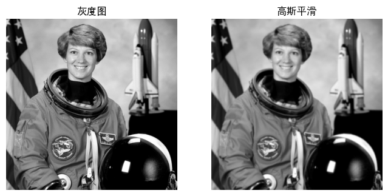

```python
astro_gray = color.rgb2gray(astro_rgb)
astro_blur = filters.gaussian(astro_gray, sigma=1.2, preserve_range=True)

plt.figure(figsize=(8,4))
plt.subplot(1,2,1); plt.imshow(astro_gray, cmap="gray"); plt.title("灰度图"); plt.axis("off")
plt.subplot(1,2,2); plt.imshow(astro_blur, cmap="gray"); plt.title("高斯平滑"); plt.axis("off")
plt.show()
```

## Step 3: 边缘检测（Canny）

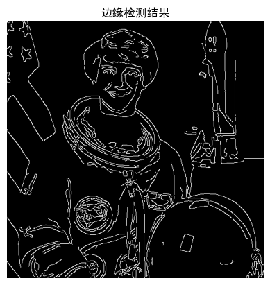

```python
astro_u8 = (util.img_as_ubyte(astro_blur))
edges = cv2.Canny(astro_u8, 60, 160).astype(bool)

plt.imshow(edges, cmap="gray")
plt.title("边缘检测结果")
plt.axis("off")
plt.show()
```

## Step 4: 填充轮廓并清理噪声

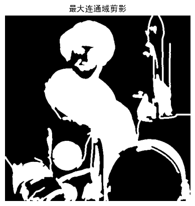

```python
edges_closed = morphology.binary_closing(edges, morphology.disk(3))
edges_dil = morphology.dilation(edges_closed, morphology.disk(2))
filled_mask = ndi.binary_fill_holes(edges_dil)
clean_mask = morphology.remove_small_objects(filled_mask, min_size=500)

# 标记连通域
label_image = measure.label(clean_mask)

# 找出最大连通域
props = measure.regionprops(label_image)
if len(props) > 0:
    largest = max(props, key=lambda p: p.area)
    astronaut_mask = (label_image == largest.label)
else:
    astronaut_mask = clean_mask

plt.imshow(astronaut_mask, cmap="gray")
plt.title("最大连通域剪影")
plt.axis("off")
plt.show()
```

## Step 5: 平滑处理并生成最终设计

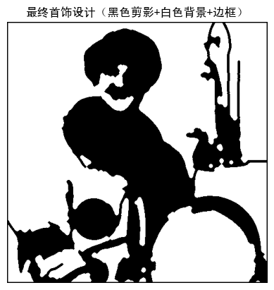

```python
# 形态学处理，填补小洞，平滑边缘
astronaut_mask = morphology.binary_closing(astronaut_mask, morphology.disk(4))
astronaut_mask = morphology.binary_opening(astronaut_mask, morphology.disk(2))

final_img = np.where(astronaut_mask, 0, 255).astype(np.uint8)

H, W = final_img.shape
# 添加边框
border_thickness = max(2, min(H, W)//200)
final_with_border = final_img.copy()
final_with_border[:border_thickness, :] = 0
final_with_border[-border_thickness:, :] = 0
final_with_border[:, :border_thickness] = 0
final_with_border[:, -border_thickness:] = 0

plt.imshow(final_with_border, cmap="gray")
plt.title("最终首饰设计（黑色剪影+白色背景+边框）")
plt.axis("off")
plt.show()
```

## Step 6: 保存 PNG 结果

```python
from imageio import imwrite
imwrite("astronaut_silhouette.png", final_with_border)
print("已保存文件：astronaut_silhouette.png")
```

```
已保存文件：astronaut_silhouette.png
```

# 学习心得：宇航员剪影首饰生成项目

本次学习通过 `astronaut_jewelry_generator.ipynb`，系统体验了图像处理在创意设计中的应用。整个流程分为六步，涵盖了从基础图像读取到最终设计输出的完整过程，收获颇丰。

## 1. 图像处理基础

首先，项目使用了 `skimage`、`matplotlib`、`scipy` 等常用库，并兼容 OpenCV。通过载入 `skimage` 自带的宇航员图片，直观展示了原始数据，为后续处理打下基础。

## 4. 设计优化与输出

进一步的形态学平滑处理让剪影边缘更自然。添加边框后，最终设计更具首饰感。最后，使用 `imageio` 保存为 PNG 文件，方便后续实际应用或展示。

# 挑战与收获

本项目不仅提升了我的 Python 图像处理能力，也让我认识到编程在创意领域的无限可能。未来希望能将这些技术应用到更多实际设计中。